# Model comparison (micro level)

Density, Time of Presence, Stop duration. Real tracks vs simulated (Unity CSV).

**Input:** DXF with floor plan, folder with real-trajectory CSVs, folder with Unity simulation CSVs.

```python
import sys
from pathlib import Path

for d in [Path.cwd(), Path.cwd() / "model_search"]:
    if (d / "density.py").exists() and str(d) not in sys.path:
        sys.path.insert(0, str(d))
        break

from micro_compare import run_density_comparison, run_top_comparison, run_stop_duration_comparison, run_global_summary
from micro_data import load_micro_data, plot_intro_tracks, plot_density_heatmaps, plot_top_heatmaps

PATH_DXF = r"C:\Users\malko\Desktop\Diploma\Term\bird-dataset-main\model_search\Floor_0.dxf"
PATH_TRAJECTORIES_CSV = "C://Users/malko/Desktop/Diploma/Term/bird-dataset-main/bird-dataset-main/data/normalized_trajectories"
CELL_SIZE_M = 1.0
PATH_UNITY_DXF = r"C:\Users\malko\Desktop\Diploma\Term\bird-dataset-main\model_search\unity_plan_and_tracks.dxf"
PATH_SIMULATION_CSV = r"C:\Users\malko\Nancy_floor0\Assets\StreamingAssets\unity_tracks_bird"

# Fixed color scale for heatmaps (same across runs)
DENSITY_VMIN, DENSITY_VMAX = 0, 175   # points
TOP_VMIN, TOP_VMAX = 0, 160           # seconds
```

```python
%pip install -q ezdxf pandas matplotlib numpy
```

## Micro level

Movement metrics per zone: density, time of presence, distribution of stop durations.

**Start of section:** floor plan + tracks + grid (real and simulated).

### Density maps

Visitor density per unit area. Grid 1×1 m (parameter `CELL_SIZE_M`).

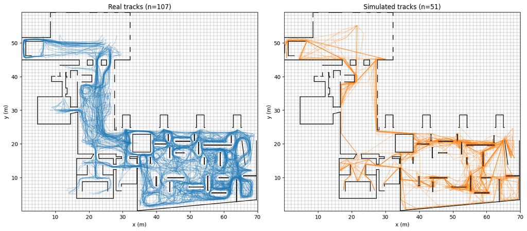

```python
# Intro: floor plan + tracks + grid (real and simulated)
d_real, d_sim, xe, ye, segments, traj_real_m, traj_sim_m = load_micro_data(
    PATH_TRAJECTORIES_CSV, PATH_SIMULATION_CSV, PATH_DXF, PATH_UNITY_DXF, CELL_SIZE_M
)
plot_intro_tracks(segments, xe, ye, traj_real_m, traj_sim_m)
```

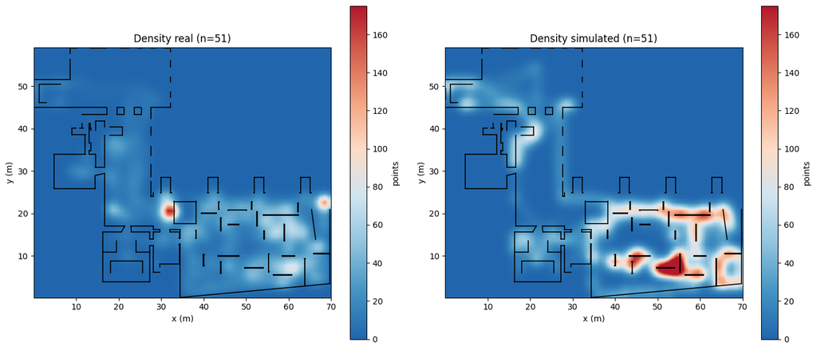

```python
# Density: real and simulated heatmaps (fixed scale for comparability)
hm_real_smooth, hm_sim_smooth = plot_density_heatmaps(
    d_real, d_sim, segments, xe, ye,
    vmin_d=DENSITY_VMIN, vmax_d=DENSITY_VMAX
)
```

### Comparison of density maps

Metrics and difference map for the density maps above (real vs simulated).

```
Correlation:
  Pearson r = 0.5111, Spearman rho = 0.7469 (p = 0.0000)
Errors:
  MAE = 17.0461, RMSE = 32.4050, NMAE = 1.5128
```

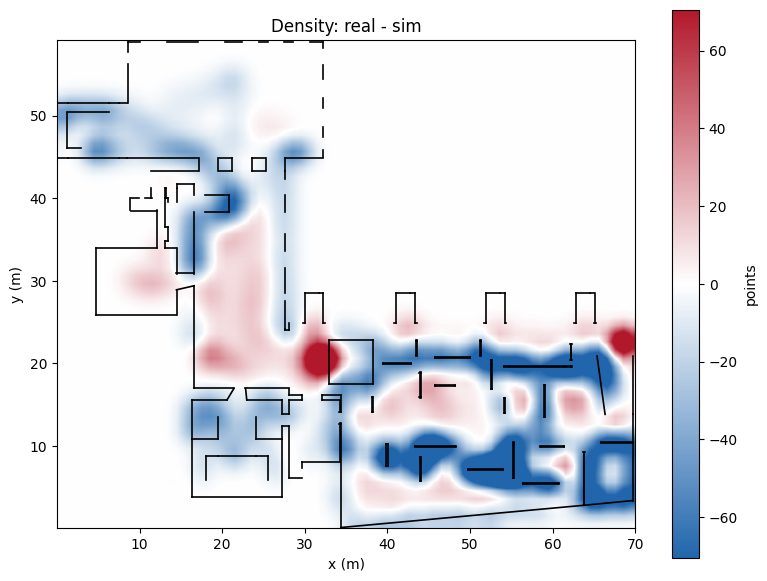

```python
# Comparison of density maps (run after Density cells above)
run_density_comparison(d_real, d_sim, hm_real_smooth, hm_sim_smooth, xe, ye, segments)
```

### Global totals (Density)

Total density (points) over the floor: real vs simulated.

```python
# Global totals — Density (run after Density comparison above)
density_real = int(d_real["heatmap"].sum())
print("Real:    total density (points) =", density_real)
if d_sim is not None:
    density_sim = int(d_sim["heatmap"].sum())
    print("Simulated: total density (points) =", density_sim)
    print("Ratio sim/real =", round(density_sim / max(density_real, 1), 4))
else:
    print("Simulated: no data")
```

```
Real:    total density (points) = 31733
Simulated: total density (points) = 64047
Ratio sim/real = 2.0183
```

### Time of Presence (ToP)

Time of presence = total time (s) per cell over all agents.

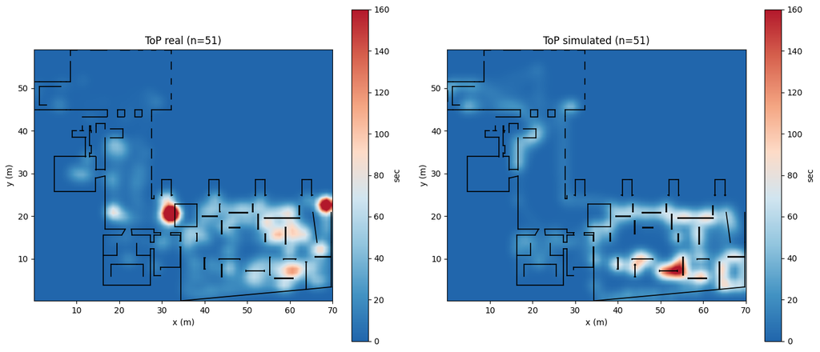

```python
# Time of Presence: fixed scale for comparability
top_real_smooth, top_sim_smooth = plot_top_heatmaps(
    d_real, d_sim, segments, xe, ye,
    vmin_t=TOP_VMIN, vmax_t=TOP_VMAX
)
```

### Comparison of ToP maps

Metrics and difference map for the Time of Presence maps above (real vs simulated).

```
Correlation:
  Pearson r = 0.4233, Spearman rho = 0.7145 (p = 0.0000)
Errors:
  MAE = 11.7406, RMSE = 25.1602, NMAE = 0.8295
```

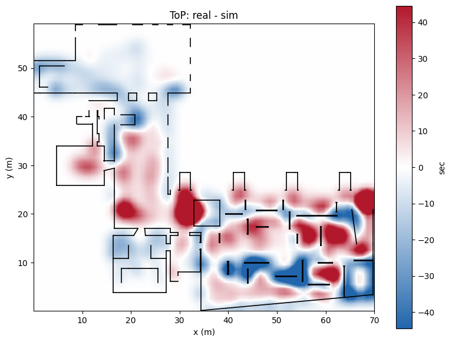

```python
# Comparison of ToP maps (run after ToP cells above)
run_top_comparison(d_real, d_sim, top_real_smooth, top_sim_smooth, xe, ye, segments)
```

### Global totals (ToP)

Total Time of Presence (seconds) over the floor: real vs simulated.

```python
# Global totals — ToP (run after ToP comparison above)
top_real_sec = float(d_real["top_matrix"].sum())
print("Real:    total ToP =", round(top_real_sec, 1), "s", f"({top_real_sec/60:.1f} min)")
if d_sim is not None:
    top_sim_sec = float(d_sim["top_matrix"].sum())
    print("Simulated: total ToP =", round(top_sim_sec, 1), "s", f"({top_sim_sec/60:.1f} min)")
    print("Ratio sim/real =", round(top_sim_sec / max(top_real_sec, 1e-9), 4))
else:
    print("Simulated: no data")
```

```
Real:    total ToP = 39134.0 s (652.2 min)
Simulated: total ToP = 36490.5 s (608.2 min)
Ratio sim/real = 0.9324
```

*(Global totals: Density above after density comparison; ToP above after ToP comparison.)*

```python
# See "Global totals (Density)" and "Global totals (ToP)" in the sections above.
```

*(Comparison of density maps is above, after Density maps; comparison of ToP maps is above, after ToP maps.)*

```python
# Comparisons are in the sections above (after Density maps and after ToP maps).
```

### Stop duration distribution

Stop duration stats (run of 2+ points in same cell): mean, median, 75th/90th percentiles, proportion of long stops.

```python
# Stop duration: real vs simulated
run_stop_duration_comparison(d_real, d_sim)
```

```
Real:
  n_stops: 4380
  mean: 8.93 s, median: 4.0 s
  75th: 10.0 s, 90th: 18.0 s
  proportion of long stops (>30.0 s): 4.61%
Simulated:
  n_stops: 7694
  mean: 4.74 s, median: 2.45 s
  75th: 4.08 s, 90th: 13.0 s
  proportion of long stops (>30.0 s): 1.20%
Comparison (real vs simulated):
  Mean stop duration: real 8.93 s, sim 4.74 s, diff = 4.19 s
  Median: real 4.0 s, sim 2.45 s, diff = 1.55 s
  Proportion long stops: real 4.61%, sim 1.20%, diff = 3.41%
```

### Global summary

Summary of real vs simulated comparison for density, ToP, and Stop duration — based on the metrics computed above.

```python
# Global summary from current analysis (run after all cells above)
run_global_summary(d_real, d_sim, hm_real_smooth, hm_sim_smooth, top_real_smooth, top_sim_smooth)
```

Global summary: real vs simulated

Density

- **Correlation:** Pearson r = 0.511, Spearman rho = 0.747 — **strong** agreement.

- **Errors:** MAE = 17.05, NMAE = 1.51 — substantial differences in magnitude.

- **Global total:** density sum real = 31733, sim = 64047, ratio sim/real = 2.018 — **simulation clearly overestimates** overall visits.

- **Targets:** Spearman ρ ≥ 0.7 (spatial pattern) ✓; NMAE ≤ 1.0 (magnitude) ✗.

Time of Presence (ToP)

- **Correlation:** Pearson r = 0.423, Spearman rho = 0.715 — **strong** agreement.

- **Errors:** MAE = 11.74 s, NMAE = 0.83 — moderate differences.

- **Global total:** ToP sum real = 39134 s (652.2 min), sim = 36490 s (608.2 min), ratio sim/real = 0.932 — **simulation slightly underestimates** presence time.

- **Targets:** Spearman ρ ≥ 0.7 (spatial pattern) ✓; NMAE ≤ 1.0 (magnitude) ✓.

Stop duration

- **Real:** n_stops = 4380, mean = 8.93 s, median = 4.0 s, proportion of long stops (>30 s) = 4.61%.

- **Simulated:** n_stops = 7694, mean = 4.74 s, median = 2.45 s, proportion long = 1.20%.

- **Comparison:** difference in means = 4.19 s; difference in proportion long = 3.41%. Real stops are on average longer — simulation produces more short dwells.

- **Targets:** |mean diff| < 3 s ✗; |proportion long diff| < 10% ✓.

Recommendations (targets to aim for)

- **Density:** Spearman ρ ≥ 0.7 for good spatial agreement; NMAE ≤ 1.0 for acceptable magnitude errors. Ratio sim/real between 0.8 and 1.2 indicates similar overall activity level.

- **ToP:** Same as density (Spearman ≥ 0.7, NMAE ≤ 1.0). Global ToP ratio near 1.0 means total presence time is well matched.

- **Stop duration:** |Difference in mean stop duration| < 3 s and |difference in proportion of long stops| < 10% suggest similar dwelling behaviour.

*Summary generated from metrics computed in the cells above.*